# Análisis descriptivo de la componnete G

Relación con el parámetro alfa

## Componente *G*

La componente *G* del costo unitario permite trasladar los costos de la compra de energía al usuario final. En esta componente se tiene en cuenta las compras en bilaterales, bolsa y futuros.

$$\begin{align}
G_{m, i, j} =\omega_{1, m-1,i} \cdot
Qc_{m-1, i} \cdot(\alpha_{i,j} \cdot Pc_{m-1,i} + (1-\alpha_{i,j})\cdot Mc_{m-1}) + \\ \qquad \omega_{2, m-1,i} \cdot Qc_{m-1, i} * PSA_{m-1,1} + CUG_{m-1,i} - EGP_{i} +\\
\sum_{l=3}^{n} \omega_{l, m-1,i} \cdot Qc_{m-1, i} \cdot P_{l, m-1, i} +
\\(1 - Qc_{m-1,i} - Qadg_{m-1, i}) \cdot Pb_{m-1,i} + \\ G\_transitorio_{m,i,j} + Aj_{m,i}
\end{align}$$

Diferentes actores del mercado han manifestado que el traslado de los costos puede no ser eficiente debido a:

- El comercializador no asume responsabilidad por su ineficiencia.
- Los costos son trasladados al usuario como un pass-through.
- Los comercializadores no están obligados a contratar quedando expuestos al precio de bolsa.
- Los contratos no quedan vinculados al despacho.
- No hay un castigo por incumplimientos
- Pueden haber oportunidades de arbitraje.

Una característica que llama la atención es que el precio promedio para los usuarios regulados es mayor que para los usuarios no regulados.

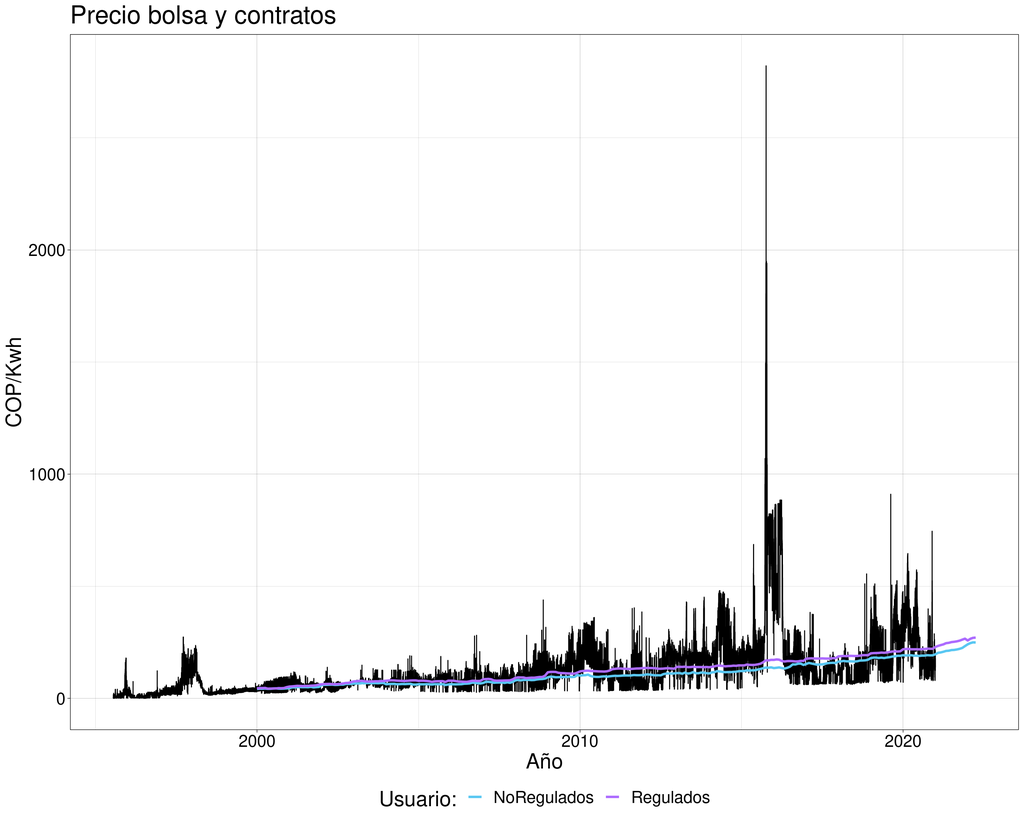

Las observaciones y la gráfica anterior lleva a pensar que el mercado de energía mayorista presenta algunas falencias.

## ¿Hay relación entre el valor $\alpha$ y el precio de los contratos?

El parámetro $\alpha$ fue introducido con un fator de eficiencia. Este valor permite identifcar si el comecializador traslada los costos propios o los del mercado como bien se puede deducir de la siguiente expresión:

$$\begin{align}
G_{m, i, j} = \alpha_{i,j} \cdot Pc_{m-1,i} + (1-\alpha_{i,j}) \cdot Mc_{m-1}
\end{align}$$

Las preguntas que se buscan responder son:

- ¿Hay relación entre el valor $\alpha$ de las comercializadoras y el precio al que adquieren los contratos?

Se busca evidenciar si para valores de $\alpha$ *‘‘grandes’’* corresponde precios de contratos altos. Esto se apoya en el hecho de que con un valor $\alpha$ cercano a 1 se pueden transferir todos los costos propios; con valores cercanos a cero se transfiere el precio del mercado.

## Datos

Con el siguiente conjunto de datos se busca evidenciar la pregunta anterior.

### Valores $\alpha$

En la tabla siguiente se encuentran los valores $\alpha$ para algunas comercializadoras.

| Comercializador | Alfa |
| --- | --- |
| GENERCAUCA | 1 |
| RUITOQUE | 0.93 |
| EEP | 0.9 |
| EMCARTAGO | 0.88 |
| MUNICIPAL | 0.87 |
| CETSA | 0.85 |
| EPM | 0.82 |
| EDEQ | 0.79 |
| PUTUMAYO | 0.78 |
| ELECTRICARIBE | 0.76 |

[output cut: 18 more lines]

### Precio de los contratos

| Codigo_Convocatoria | Codigo_Producto | Codigo_SIC_Agente | Nombre_Corto | Estado_Convocatoria | Mercado | Fecha_Actualizacion_Estado_Convocatoria | Inicio_Periodo_Contratar | Fin_Periodo_Contratar | Fecha_Publicacion_Aviso | Fecha_Pliegos_Para_Consulta | Fecha_Pliegos_Definitivos | Fecha_Limite_Recepcion_Ofertas | Fecha_Audiencia_Publica | Cantidad_Energia_Demandada_GWh | Cantidad_Energia_Adjudicada_GWh | Promedio_Ponderado_Convocatoria_COP/kWh |
| --- | --- | --- | --- | --- | --- | --- | --- | --- | --- | --- | --- | --- | --- | --- | --- | --- |
| CP-EPIC2020-001 | CP-EPIC2020-001-PROD04 | EPIC | CELSIA TOLIMA | Cerrada y adjudicada | Regulado | 2020-04-28 | 2023-01-01 | 2023-12-31 | 2020-02-03 | 2020-02-03 | 2020-02-24 | 2020-03-24T15:00:00Z | 2020-04-03T14:00:00Z | 302.94 | 302.94 | 199.96 |
| CP-NMRC2020-001 | CP-NMRC2020-001-PROD01 | NMRC | ENER+ | Cerrada y adjudicada | Regulado | 2020-04-29 | 2020-06-01 | 2020-12-31 | 2020-01-30 | 2020-02-03 | 2020-02-24 | 2020-03-24T11:00:00Z | 2020-04-06T14:00:00Z | 5.1 | 5.1 | 230 |
| CP-NMRC2020-001 | CP-NMRC2020-001-PROD02 | NMRC | ENER+ | Cerrada y adjudicada | Regulado | 2020-04-29 | 2021-01-01 | 2021-12-31 | 2020-01-30 | 2020-02-03 | 2020-02-24 | 2020-03-24T11:00:00Z | 2020-04-06T14:00:00Z | 8.7 | 0 | 0 |
| CP-EDIC2020-001 | CP-EDIC2020-001-PROD01 | EDIC | ELECTRICARIBE | Cerrada y adjudicada | Regulado | 2020-06-01 | 2020-05-15 | 2025-12-31 | 2020-02-11 | 2020-02-11 | 2020-03-02 | 2020-03-31T15:00:00Z | 2020-04-15T09:00:00Z | 4994.14 | 2566.15 | 200.45 |
| CP-EDIC2020-001 | CP-EDIC2020-001-PROD02 | EDIC | ELECTRICARIBE | Cerrada y adjudicada | Regulado | 2020-06-01 | 2020-05-15 | 2025-12-31 | 2020-02-11 | 2020-02-11 | 2020-03-02 | 2020-03-31T15:00:00Z | 2020-04-15T09:00:00Z | 9753.7 | 3529.11 | 201.52 |
| CP-PEEC2020-002 | CP-PEEC2020-002-PROD01 | PEEC | PEESA | Cerrada y adjudicada | Regulado | 2020-06-03 | 2020-06-01 | 2022-12-31 | 2020-03-03 | 2020-03-04 | 2020-03-26 | 2020-04-27T23:59:00Z | 2020-05-08T15:00:00Z | 430.5 | 268.05 | 227.8 |
| CP-GNCC2020-001 | CP-GNCC2020-001-PROD01 | GNCC | VATIA | Cerrada y adjudicada | Regulado | 2020-06-04 | 2020-08-01 | 2020-12-31 | 2020-02-20 | 2020-02-20 | 2020-03-12 | 2020-04-29T18:00:00Z | 2020-04-28T14:00:00Z | 40 | 0 | 0 |
| CP-GNCC2020-001 | CP-GNCC2020-001-PROD02 | GNCC | VATIA | Cerrada y adjudicada | Regulado | 2020-06-04 | 2021-01-01 | 2021-12-31 | 2020-02-20 | 2020-02-20 | 2020-03-12 | 2020-04-29T18:00:00Z | 2020-04-28T14:00:00Z | 300 | 0 | 0 |
| CP-GNCC2020-001 | CP-GNCC2020-001-PROD03 | GNCC | VATIA | Cerrada y adjudicada | Regulado | 2020-06-04 | 2022-01-01 | 2022-12-31 | 2020-02-20 | 2020-02-20 | 2020-03-12 | 2020-04-29T18:00:00Z | 2020-04-28T14:00:00Z | 300 | 0 | 0 |
| CP-GNCC2020-001 | CP-GNCC2020-001-PROD04 | GNCC | VATIA | Cerrada y adjudicada | Regulado | 2020-06-04 | 2023-01-01 | 2023-12-31 | 2020-02-20 | 2020-02-20 | 2020-03-12 | 2020-04-29T18:00:00Z | 2020-04-28T14:00:00Z | 252 | 0 | 0 |

[output cut: 354 more lines]

### Datos para el análisis

Con las tablas anteriores se crea una nueva donde coincida el nombre del comercializador.

| comercializador | alfas | Mercado | Inicio_Periodo_Contratar | Fin_Periodo_Contratar | Cantidad_Energia_Demandada_GWh | Cantidad_Energia_Adjudicada_GWh | Promedio_Ponderado_Convocatoria_COP/kWh | dias_contratados |
| --- | --- | --- | --- | --- | --- | --- | --- | --- |
| RUITOQUE | 0.93 | Regulado | 2021-01-01 | 2030-12-31 | 168.04 | 114.71 | 198.67 | 3651 |
| RUITOQUE | 0.93 | Regulado | 2021-01-01 | 2030-12-31 | 157.84 | 0 | 0 | 3651 |
| RUITOQUE | 0.93 | Regulado | 2021-04-01 | 2021-12-31 | 8.8 | 0 | 0 | 274 |
| RUITOQUE | 0.93 | Regulado | 2022-01-01 | 2022-12-31 | 8.33 | 0 | 0 | 364 |
| RUITOQUE | 0.93 | Regulado | 2023-01-01 | 2023-12-31 | 16.61 | 0 | 0 | 364 |
| RUITOQUE | 0.93 | Regulado | 2025-01-01 | 2025-12-31 | 19.2 | 19.2 | 193.34 | 364 |
| RUITOQUE | 0.93 | Regulado | 2021-10-19 | 2021-12-31 | 3.95 | 3.95 | 185.75 | 73 |
| RUITOQUE | 0.93 | Regulado | 2021-10-19 | 2021-12-31 | 2.64 | 2.64 | 186.61 | 73 |
| RUITOQUE | 0.93 | Regulado | 2022-01-01 | 2022-12-31 | 15.63 | 15.63 | 245 | 364 |
| RUITOQUE | 0.93 | Regulado | 2022-01-01 | 2022-12-31 | 10.05 | 0 | 0 | 364 |

[output cut: 193 more lines]

## Análisis

Las gráficas siguientes tienen información de los contratos a partir del año 2020. Para este periodo solo se tienen ofertas cerradas y adjudicadas para el mercado regulado.

### Precio vs demanda

El precio parece no verse afectado por el volumen ya que para diferentes cantidades el nivel del precio es similar. Lo extraño es que para precios inferiores a $1000 \, Gwh$ el precio es muy volátil.

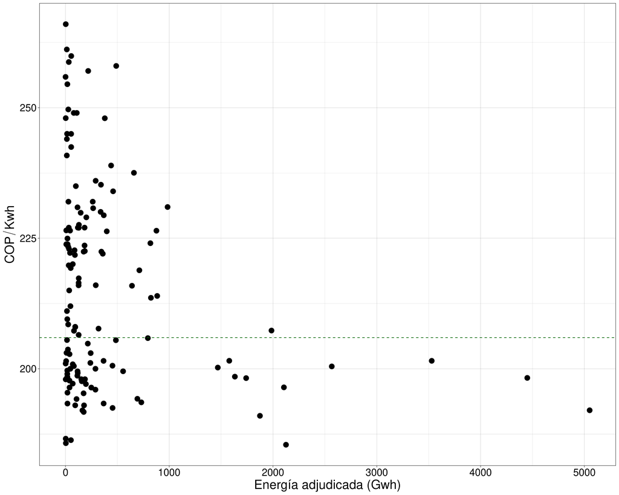

### Precio vs alfa

Al igual que el gráfico anterior no se evidencia una relación entre el ponderador y el precio.

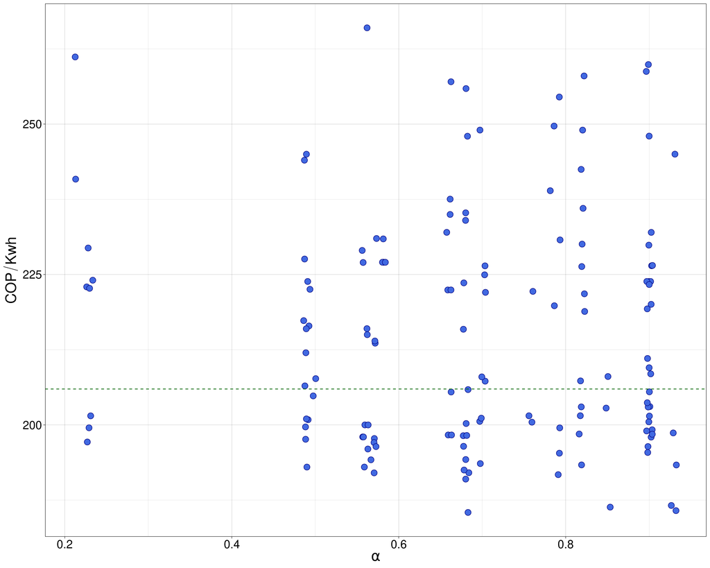

### Precio vs alfa + volumen

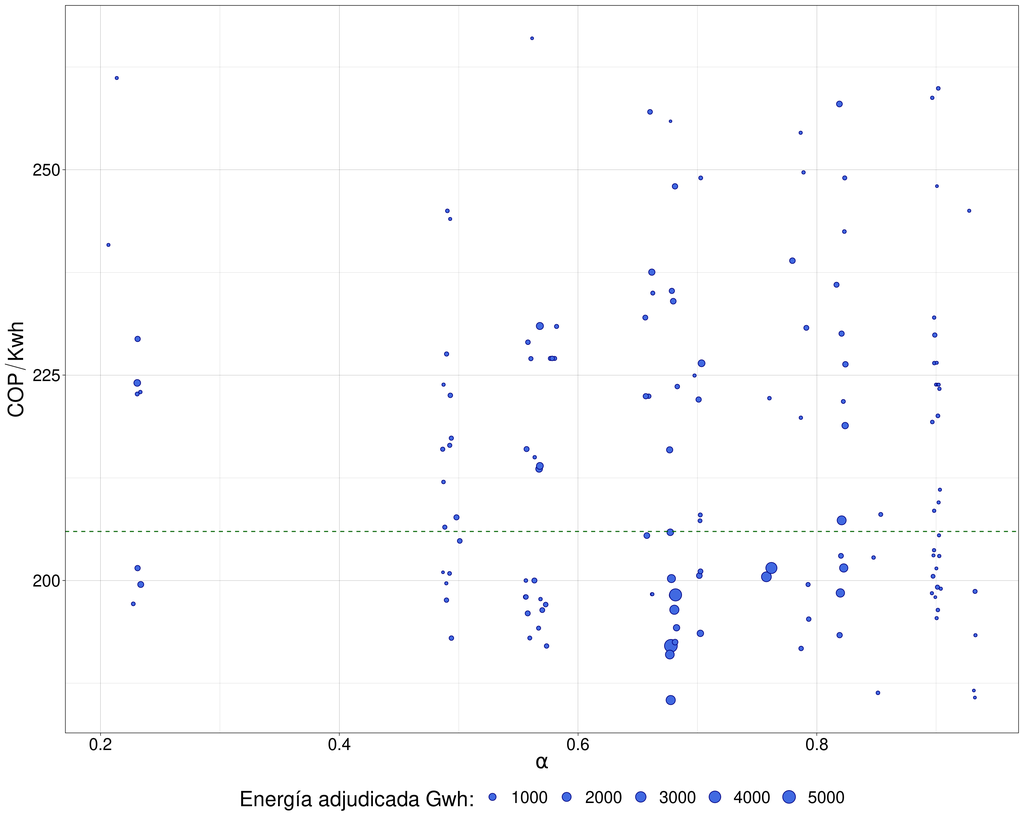

### Precio vs alfa + volumen + duración del contrato

Son pocos los contratos que se negocián a largo plazo.

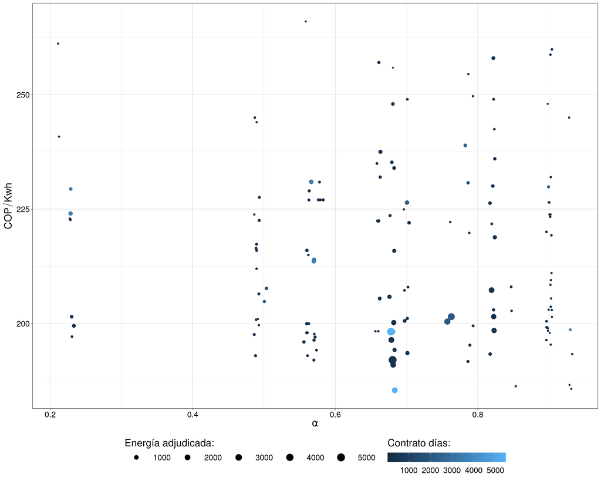

### Precios vs comercializador + volumen

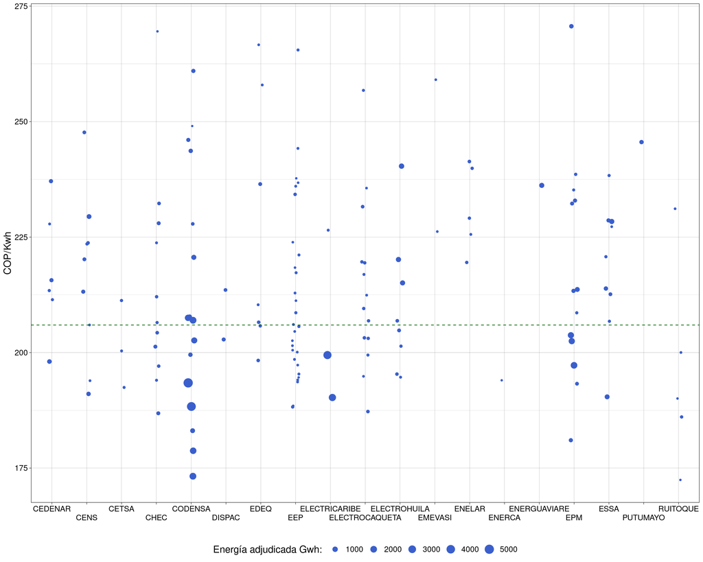

### Gráfico de densidad.

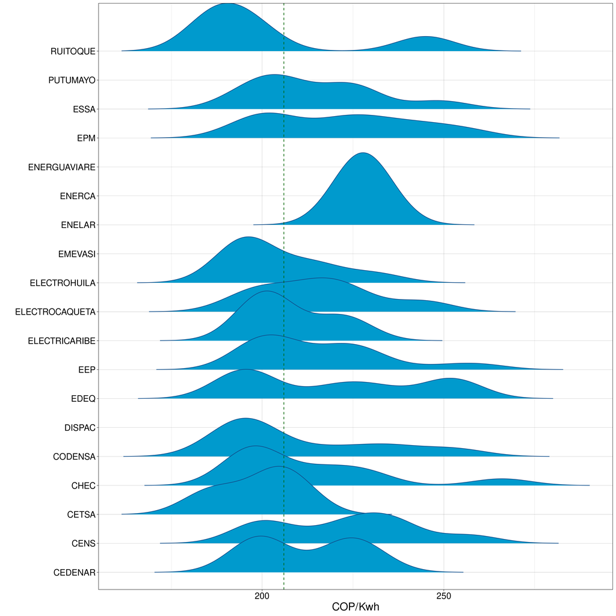

### Promedio del mercado vs promedio del comercializador.

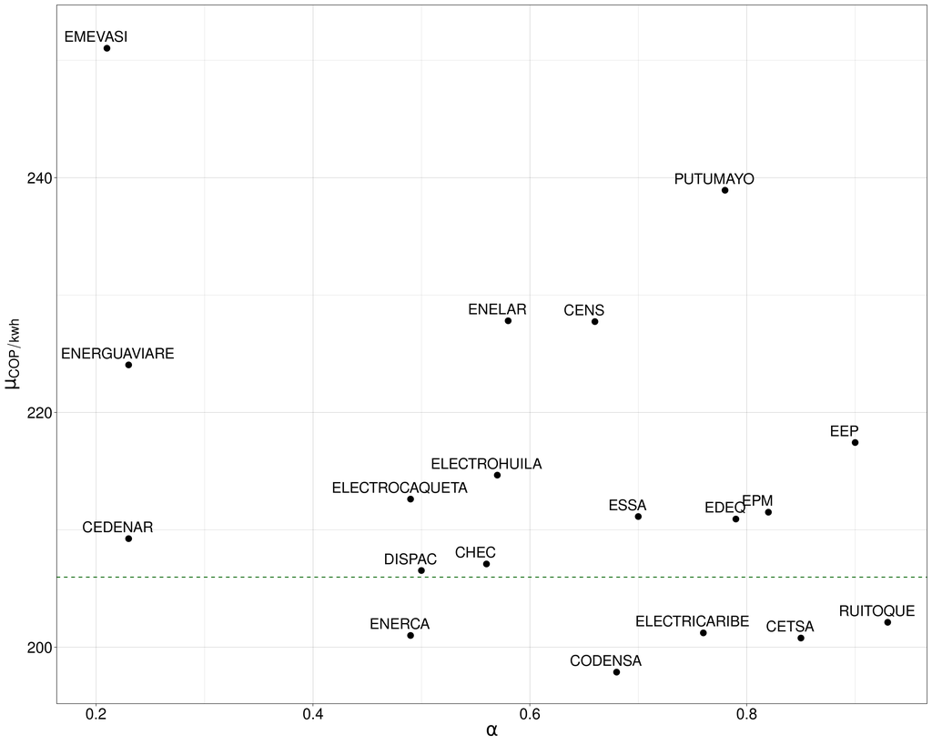

### $\alpha = 0.5$ vertical

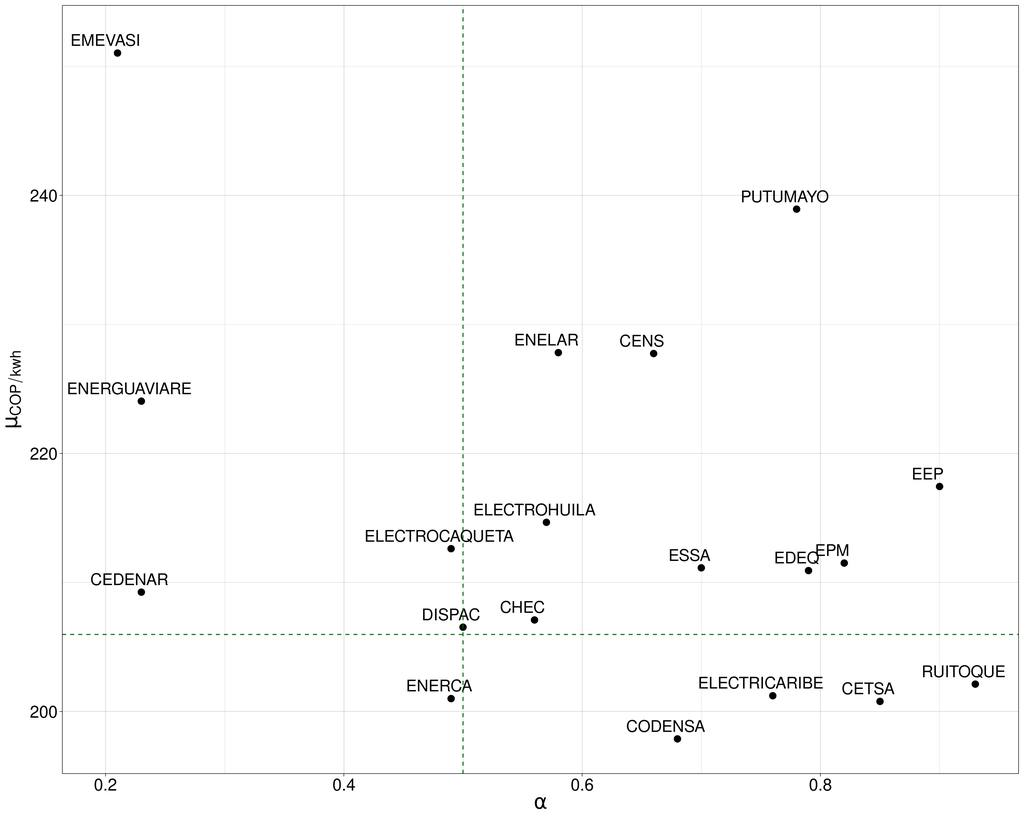

### EPM y CODENSA: Precio vs Inicio del contratos y volumen.

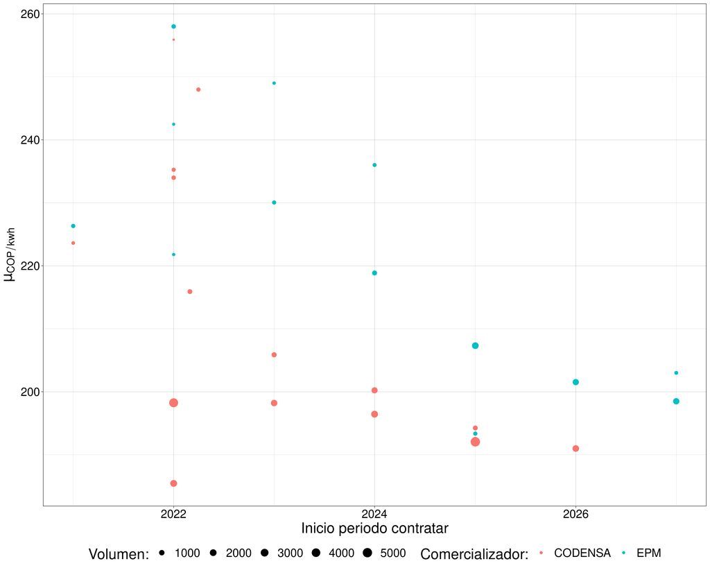